# Домашнее задание №1

## Работа с данными

1. Загрузите данные в датафрейм, который назовите data.df

```r
data.df <- read.table("http://www.stats.uwo.ca/faculty/braun/data/rnf6080.dat")
```

2. Сколько строк и столбцов в data.df? Если получилось не 5070 наблюдений 27 переменных, то проверяйте аргументы

```r
paste("data.df loaded: ", nrow(data.df), " observations and ", ncol(data.df), " variables")
```

```
## [1] "data.df loaded:  5070  observations and  27  variables"
```

Импорт данных прошел успешно!

3. Получите имена колонок из data.df

```r
colnames(data.df)
```

```
##  [1] "V1"  "V2"  "V3"  "V4"  "V5"  "V6"  "V7"  "V8"  "V9"  "V10" "V11"
## [12] "V12" "V13" "V14" "V15" "V16" "V17" "V18" "V19" "V20" "V21" "V22"
## [23] "V23" "V24" "V25" "V26" "V27"
```

4. Найдите значение из 5 строки седьмого столбца

```r
data.df[5, 7]
```

```
## [1] 0
```

5. Напечатайте целиком 2 строку из data.df

```r
data.df[2,]
```

```
##   V1 V2 V3 V4 V5 V6 V7 V8 V9 V10 V11 V12 V13 V14 V15 V16 V17 V18 V19 V20
## 2 60  4  2  0  0  0  0  0  0   0   0   0   0   0   0   0   0   0   0   0
##   V21 V22 V23 V24 V25 V26 V27
## 2   0   0   0   0   0   0   0
```

6. Объясните, что делает следующая строка кода names(data.df) <- c(“year”, “month”, “day”, seq(0,23))

```r
names(data.df)
```

```
##  [1] "V1"  "V2"  "V3"  "V4"  "V5"  "V6"  "V7"  "V8"  "V9"  "V10" "V11"
## [12] "V12" "V13" "V14" "V15" "V16" "V17" "V18" "V19" "V20" "V21" "V22"
## [23] "V23" "V24" "V25" "V26" "V27"
```

```r
names(data.df) <- c("year", "month", "day", seq(0, 23))
```

Данная строка изменяет название колонок

7. Воспользуйтесь функциями head и tail, чтобы просмотреть таблицу. Что представляют собой последние 24 колонки?

```r
tail(data.df)
```

```
##      year month day 0 1 2 3 4 5 6 7 8 9 10 11 12 13 14 15 16 17 18 19 20
## 5065   80    11  25 0 0 0 0 0 0 0 0 0 0  0  0  0  0  0  0  0  0  0  0  0
## 5066   80    11  26 0 0 0 0 0 0 0 0 0 0  0  0  0  0  0  0  0  0  0  0  0
## 5067   80    11  27 0 0 0 0 0 0 0 0 0 0  0  0  0  0  0  0  0  0  0  0  0
## 5068   80    11  28 0 0 0 0 0 0 0 0 0 0  0  0  0  0  0  0  0  0  0  0  0
## 5069   80    11  29 0 0 0 0 0 0 0 0 0 0  0  0  0  0  0  0  0  0  0  0  0
## 5070   80    11  30 0 0 0 0 0 0 0 0 0 0  0  0  0  0  0  0  0  0  0  0  0
##      21 22 23
## 5065  0  0  0
## 5066  0  0  0
## 5067  0  0  0
## 5068  0  0  0
## 5069  0  0  0
## 5070  0  0  0
```

Последние 24 колонки показывают количество осадков по часам

8. Добавьте новую колонку с названием daily, в которую запишите сумму крайних правых 24 колонок. Постройте гистограмму по этой колонке. Какие выводы можно сделать?

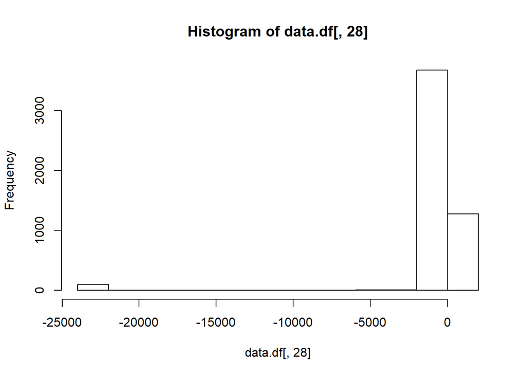

```r
data.df$daily <- rowSums(data.df[, 4:27])
hist(data.df[, 28])
```

В данных присутствуют ошибки (выбросы)

9. Создайте новый датафрейм fixed.df в котром исправьте замеченную ошибку. Постройте новую гистограмму, поясните почему она более корректна

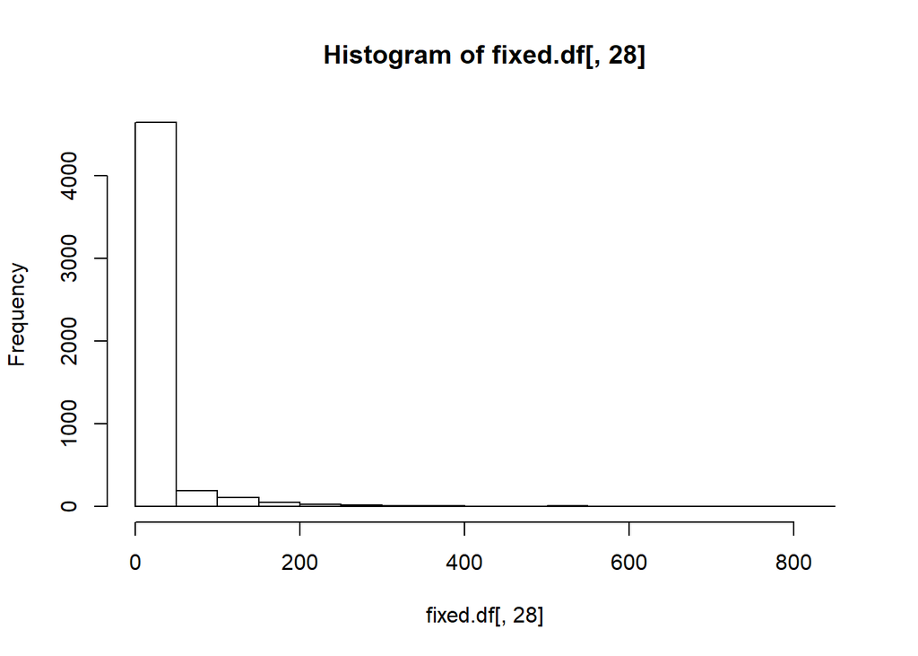

```r
fixed.df <- data.df
fixed.df$daily[which(fixed.df$daily < 0)] = 0
hist(fixed.df[, 28])
```

Некорректные данные были обнулены. На новой гистограмме отсутствуют некорректные (отрицательные) значения количества осадков

## Синтаксис и типизирование

1. Для каждой строки кода поясните полученный результат, либо объясните почему она ошибочна

```r
v <- c("4", "8", "15", "16", "23", "42") #вектору присваиваются символы, а не числа, соответсвенно дальнейшие действия будут произведены с кодами соответствующих символов
max(v)
```

```
## [1] "8"
```

```r
sort(v)
```

```
## [1] "15" "16" "23" "4"  "42" "8"
```

```r
sum(as.integer(v)) # посчитать сумму от символов невозможно
```

```
## [1] 108
```

Исправить проблему можно 2 способами: либо присвоить вектору числа, либо рассматривать каждый элемент вектора как число

2. Для следующих наборов команд поясните полученный результат, либо объясните почему они ошибочна

```r
v2 <- c("5", 7, 12)
as.integer(v2[2]) + as.integer(v2[3]) # Все элементы вектора должны быть одного типа, поэтому в данном случае они инициализируются как *char*, а значит арифметические операции неприменимы
```

```
## [1] 19
```

```r
df3 <- data.frame(z1 = "5", z2 = 7, z3 = 12)
df3[1, 2] + df3[1, 3]
```

```
## [1] 19
```

```r
# С dataframe и list дела обстоят иначе: элементы разных типов можно встретить в пределах одного фрейма
l4 <- list(z1 = "6", z2 = 42, z3 = "49", z4 = 126)
l4[[2]] + l4[[4]]
```

```
## [1] 168
```

```r
as.integer(l4[2]) + as.integer(l4[4])
```

```
## [1] 168
```

В списках *list* адресация [] - выводит список элементов по индексу, а [[]] - сам элемент

## Работа с функциями и операторами

1. выведите на экран:
   - Числа от 1 до 10000 с инкрементом 372

```r
seq(from = 1, to = 10000, by = 372)
```

```
##  [1]    1  373  745 1117 1489 1861 2233 2605 2977 3349 3721 4093 4465 4837
## [15] 5209 5581 5953 6325 6697 7069 7441 7813 8185 8557 8929 9301 9673
```

```
+ Числа от 1 до 10000 длиной 50
```

```r
seq(from = 1, to = 10000, length.out = 50)
```

```
##  [1]     1.0000   205.0612   409.1224   613.1837   817.2449  1021.3061
##  [7]  1225.3673  1429.4286  1633.4898  1837.5510  2041.6122  2245.6735
## [13]  2449.7347  2653.7959  2857.8571  3061.9184  3265.9796  3470.0408
## [19]  3674.1020  3878.1633  4082.2245  4286.2857  4490.3469  4694.4082
## [25]  4898.4694  5102.5306  5306.5918  5510.6531  5714.7143  5918.7755
## [31]  6122.8367  6326.8980  6530.9592  6735.0204  6939.0816  7143.1429
## [37]  7347.2041  7551.2653  7755.3265  7959.3878  8163.4490  8367.5102
## [43]  8571.5714  8775.6327  8979.6939  9183.7551  9387.8163  9591.8776
## [49]  9795.9388 10000.0000
```

2. Объясните разницу между rep(1:5,times=3) и rep(1:5, each=3)

```r
rep(1:5, times = 3)
```

```
##  [1] 1 2 3 4 5 1 2 3 4 5 1 2 3 4 5
```

```r
rep(1:5, each = 3)
```

```
##  [1] 1 1 1 2 2 2 3 3 3 4 4 4 5 5 5
```

Очевидно что первый вариант повторяет всю последовательность 3 раза, а второй - повторяет каждый элемент последовательности